# Machine Learning Assignment

Isabelle Petoud

12/12/2018

# Summary of project’s goal

The goal is to use data from accelerometers on the belt, forearm, arm, and dumbell of 6 participants to predict how they did the exercices. They were asked to perform barbell lifts correctly and incorrectly in 5 different ways. This is what the “classe” variable represents in the data and what needs to be predicted on the sample.

# References

[1] Original site: http:/groupware.les.inf.puc-rio.br/har  
[2] Citation to use the data: Velloso, E.; Bulling, A.; Gellersen, H.; Ugulino, W.; Fuks, H. Qualitative Activity Recognition of Weight Lifting Exercises. Proceedings of 4th International Conference in Cooperation with SIGCHI (Augmented Human ’13) . Stuttgart, Germany: ACM SIGCHI, 2013.  
[3] Data set: https://d396qusza40orc.cloudfront.net/predmachlearn/pml-training.csv  
[4] Test set: https://d396qusza40orc.cloudfront.net/predmachlearn/pml-testing.csv

# How I built my model

Use the question -> input data -> features -> algorithm -> parameters -> evaluation.  
Question and input data are given. So let’s talk about the features. Clean up the data to keep only the data given by the sensors.

## Data cleansing

First, read the files with training and testing data.

```r
## clear the environment
rm(list=ls())
## read the files
inTrain <- read.csv("/final/pml-training.csv")
inTest <- read.csv("/final/pml-testing.csv")
```

Some validations such as verifying that the columns’ names are the same were performed (not shown here).

Then by looking at the data, there are many features that have almost only NAs.

**nearZeroVar** is in the **caret** package that has to be loaded through the **library** command.

```r
## remove variables that are almost always NA
mostlyNA <- sapply(inTrain, function(x) mean(is.na(x)) > 0.90)
inTrain <- inTrain[, !mostlyNA]
inTest <- inTest[, !mostlyNA]

## remove variables with nearly zero variance
library(caret)
nzv <- nearZeroVar(inTrain)
inTrain <- inTrain[, -nzv]
inTest <- inTest[, -nzv]

## remove variables that are not measures i.e. the first 7 columns
inTrain <- inTrain[, -(1:7)]
inTest <- inTest[, -(1:7)]
```

With summary(), str() or head() it is possible to have a look at the cleaned data.  
From 160 variables, we came down to 52 including classe.

We need to use algorithm that can handle classification. I choose **decision trees** and **random forests**.

## First method : Decision Trees

Let’s start with decision trees. We set the seed in order to get the same results at each run.

```r
## specifying outcome variable as factor
inTrain$classe<-as.factor(inTrain$classe)
set.seed(1237)
trainpart <- createDataPartition(y=inTrain$classe, p=0.6, list = FALSE)
## taking 60% for training set and 40% for testing set
training <- inTrain[trainpart, ]
test <- inTrain[-trainpart, ]
```

In order to limit the effects of overfitting, and improve the efficicency of the models, we will use the **cross-validation** technique.  
We will use 5 folds which normally gives good results.  
Then apply the algorithm for **rpart** from the caret package.  
We define the corresponding parameter to pass to the train function.

```r
trControl <- trainControl(method="cv", number=5, verboseIter=FALSE)
```

and then use it.

```r
modFitDT <- train(classe ~ .,method="rpart",data=training,trControl=trControl)
print(modFitDT$finalModel)
```

```
## n= 11776
##
## node), split, n, loss, yval, (yprob)
##       * denotes terminal node
##
##   1) root 11776 8428 A (0.28 0.19 0.17 0.16 0.18)
##     2) pitch_forearm< -26.6 1074   53 A (0.95 0.049 0 0 0) *
##     3) pitch_forearm>=-26.6 10702 8375 A (0.22 0.21 0.19 0.18 0.2)
##       6) accel_belt_z>=-186.5 10035 7715 A (0.23 0.22 0.2 0.19 0.15)
##        12) yaw_belt>=169.5 479   56 A (0.88 0.05 0 0.061 0.0063) *
##        13) yaw_belt< 169.5 9556 7354 B (0.2 0.23 0.21 0.2 0.16)
##          26) magnet_dumbbell_z< -88.5 1217  531 A (0.56 0.29 0.049 0.07 0.03) *
##          27) magnet_dumbbell_z>=-88.5 8339 6345 C (0.15 0.22 0.24 0.22 0.18)
##            54) pitch_belt< -42.85 516   95 B (0.029 0.82 0.099 0.019 0.037) *
##            55) pitch_belt>=-42.85 7823 5880 C (0.15 0.18 0.25 0.23 0.18)
##             110) magnet_dumbbell_x>=-446.5 3392 2441 B (0.16 0.28 0.091 0.23 0.24)
##               220) yaw_belt< 4.41 3070 2119 B (0.18 0.31 0.094 0.25 0.16)
##                 440) accel_dumbbell_y< 48.5 1803 1155 D (0.26 0.19 0.14 0.36 0.045)
##                   880) magnet_belt_z< -377.5 738  333 A (0.55 0.22 0.037 0.098 0.099) *
##                   881) magnet_belt_z>=-377.5 1065  489 D (0.064 0.18 0.21 0.54 0.0075) *
##                 441) accel_dumbbell_y>=48.5 1267  666 B (0.058 0.47 0.03 0.1 0.33) *
##               221) yaw_belt>=4.41 322   19 E (0 0 0.059 0 0.94) *
##             111) magnet_dumbbell_x< -446.5 4431 2796 C (0.15 0.11 0.37 0.23 0.14) *
##       7) accel_belt_z< -186.5 667    7 E (0.01 0 0 0 0.99) *
```

And plot the decision tree.

```r
library(rattle)
```

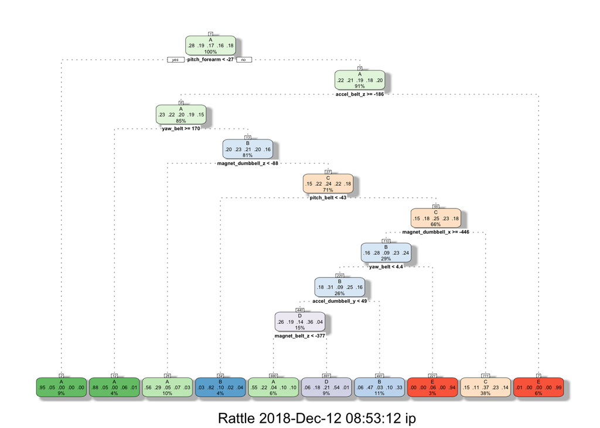

```r
fancyRpartPlot(modFitDT$finalModel)
```

And then predict on the test set

```r
predictionsDT <- predict(modFitDT,newdata=test)
```

```r
confusionMatrix(test$classe, predictionsDT)
```

```
## Confusion Matrix and Statistics
##
##           Reference
## Prediction    A    B    C    D    E
##          A 1676   56  437   54    9
##          B  353  704  305  155    1
##          C   46   54 1080  177   11
##          D  124   91  669  402    0
##          E   73  316  484    5  564
##
## Overall Statistics
##
##                Accuracy : 0.5641
##                  95% CI : (0.5531, 0.5751)
##     No Information Rate : 0.3792
##     P-Value [Acc > NIR] : < 2.2e-16
##
##                   Kappa : 0.449
##  Mcnemar's Test P-Value : < 2.2e-16
##
## Statistics by Class:
##
##                      Class: A Class: B Class: C Class: D Class: E
## Sensitivity            0.7377  0.57658   0.3630  0.50694  0.96410
## Specificity            0.9003  0.87713   0.9409  0.87466  0.87908
## Pos Pred Value         0.7509  0.46377   0.7895  0.31260  0.39112
## Neg Pred Value         0.8938  0.91830   0.7075  0.94040  0.99672
## Prevalence             0.2896  0.15562   0.3792  0.10107  0.07456
## Detection Rate         0.2136  0.08973   0.1376  0.05124  0.07188
## Detection Prevalence   0.2845  0.19347   0.1744  0.16391  0.18379
## Balanced Accuracy      0.8190  0.72685   0.6519  0.69080  0.92159
```

We can see that the accuracy is low (56%).

## Second method : Random Forest

Let’s use random forest with the same parameter for cross validation.

```r
set.seed(1237)
modelFitRF <- train(classe ~., data=training, method="rf",prox = TRUE,
                trControl=trControl)
modelFitRF$finalModel
```

```
##
## Call:
##  randomForest(x = x, y = y, mtry = param$mtry, proximity = TRUE)
##                Type of random forest: classification
##                      Number of trees: 500
## No. of variables tried at each split: 26
##
##         OOB estimate of  error rate: 0.82%
## Confusion matrix:
##      A    B    C    D    E  class.error
## A 3345    1    1    0    1 0.0008960573
## B   20 2248   10    1    0 0.0136024572
## C    0   15 2034    4    1 0.0097370983
## D    0    0   29 1898    3 0.0165803109
## E    0    1    3    6 2155 0.0046189376
```

```r
predictionsRF <- predict(modelFitRF,newdata=test)
confusionMatrix(test$classe, predictionsRF)
```

```
## Confusion Matrix and Statistics
##
##           Reference
## Prediction    A    B    C    D    E
##          A 2228    3    1    0    0
##          B   11 1502    4    0    1
##          C    0    6 1356    6    0
##          D    0    0    9 1275    2
##          E    0    0    3    7 1432
##
## Overall Statistics
##
##                Accuracy : 0.9932
##                  95% CI : (0.9912, 0.9949)
##     No Information Rate : 0.2854
##     P-Value [Acc > NIR] : < 2.2e-16
##
##                   Kappa : 0.9915
##  Mcnemar's Test P-Value : NA
##
## Statistics by Class:
##
##                      Class: A Class: B Class: C Class: D Class: E
## Sensitivity            0.9951   0.9940   0.9876   0.9899   0.9979
## Specificity            0.9993   0.9975   0.9981   0.9983   0.9984
## Pos Pred Value         0.9982   0.9895   0.9912   0.9914   0.9931
## Neg Pred Value         0.9980   0.9986   0.9974   0.9980   0.9995
## Prevalence             0.2854   0.1926   0.1750   0.1642   0.1829
## Detection Rate         0.2840   0.1914   0.1728   0.1625   0.1825
## Detection Prevalence   0.2845   0.1935   0.1744   0.1639   0.1838
## Balanced Accuracy      0.9972   0.9958   0.9929   0.9941   0.9982
```

We can see that the accuracy is quite good (more than 99%).

### How I used cross validation

As already explained, by fixing the trControl parameter in the train method the caret package will use 5 folds to perform cross validation.

### What I think the expected out of sample error is

The expected out of sample error is computed as **1-accuracy**  
This means for the decision tree:  
Approximatly 44%  
and for random forest:  
Approximatly 1%

### Why I made the choices I did.

I choose decision trees because it is a model easy to interpret.  
I choose random forest because it gives good results

### Usage of my prediction model to predict 20 different test cases.

Predict with Random Forest as it has the best accuracy

```r
predict(modelFitRF,newdata=inTest)
```

```
##  [1] B A B A A E D B A A B C B A E E A B B B
## Levels: A B C D E
```

### Conclusion

As expected the random forest algorithm gives the best results with an accuracy of more than 99%.